# Practical Machine Learning | Course Project

# 1. Introduction

The goal of this project is to predict the manner in which barbell lifts have been done correctly or incorrectly in 5 different ways. This is the “classe” variable in the training set. Details on the background and data can be found at [Coursera Project Instructions](https://www.coursera.org/learn/practical-machine-learning/supplement/PvInj/course-project-instructions-read-first%5D) or [Human Active Recognition](https://web.archive.org/web/20161224072740/http:/groupware.les.inf.puc-rio.br/har) (via web.archive.org). The approach is to

1. download and pre-process the data to enable and speed-up typical ML algorithms
2. apply some suitable algorithms and compare accuracy
3. select the best algorithm and apply it to the task of 20 test cases.
4. All training, predicting and evaluation is done with the caret package.

[output not shown]

# 2. Data

The data can be downloaded from here: [training](https://d396qusza40orc.cloudfront.net/predmachlearn/pml-training.csv) and [task/validation](https://d396qusza40orc.cloudfront.net/predmachlearn/pml-testing.csv). It consists of 160 variables and ~20.000 rows (training) and 20 rows (task/validation), respectively. We clean the data and remove:

- first 5 columns as they do not help predicting
- columns without relevant content ““,”#DIV/0!“, …
- columns containing NA values
- columns containing “near zero variance”

```
   A    B    C    D    E
3906 2658 2396 2252 2525
```

The outcome is in the variable “classe” (last column) is one out of “A”, “B”, “C”, “D”, “E”. Class “A” corresponds to the specified execution of the exercise, while the other 4 classes correspond to common mistakes.

# 3. Modelling

## 3.1 Decision tree (rpart)

The first model to try is a decision tree with 5-fold cross-validation:

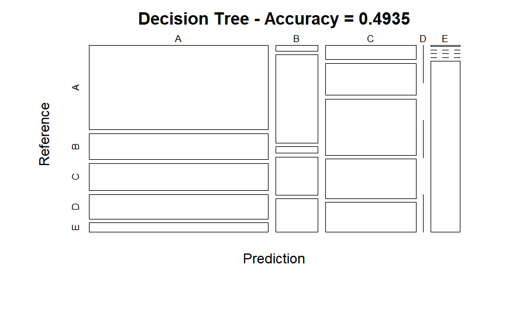

```r
#specify the cross-validation method
ctrl <- trainControl(method = "cv", number = 5)

fit_tree <- train(classe ~.,
             method="rpart",
             data =training_final,
             trControl = ctrl,
             na.action = na.exclude)

predict_tree <- predict(fit_tree, testing_final)

#fancyRpartPlot(fit_tree$finalModel)

cm_tree <- confusionMatrix(predict_tree, testing_final$classe)

plot(cm_tree$table,
     col = cm_tree$byClass,
     main = paste("Decision Tree - Accuracy =",
                  round(cm_tree$overall['Accuracy'],
                        4)))
```

The classification tree achieves an accuracy of only 0.4934579 - so rather low. Classe “D” has not been assigned at all.

## 3.2 Linear Discriminant Analysis

The second model is of type LDA, also with 5-fold cross-validation:

```r
#specify the cross-validation method
ctrl <- trainControl(method = "cv", number = 5)

fit_lda <- train(classe ~.,
             method="lda",
             data =training_final,
             trControl = ctrl,
             na.action = na.exclude)

predict_lda <- predict(fit_lda, testing_final)

cm_lda <- confusionMatrix(predict_lda, testing_final$classe)
cm_lda
```

```
Confusion Matrix and Statistics

          Reference
Prediction    A    B    C    D    E
         A 1390  162   93   52   38
         B   37  735   79   43  170
         C  110  151  687  123  106
         D  127   44  130  717  100
         E   10   47   37   29  668

Overall Statistics

               Accuracy : 0.7132
                 95% CI : (0.7014, 0.7247)
    No Information Rate : 0.2845
    P-Value [Acc > NIR] : < 2.2e-16

                  Kappa : 0.6371

 Mcnemar's Test P-Value : < 2.2e-16

Statistics by Class:

                     Class: A Class: B Class: C Class: D Class: E
Sensitivity            0.8303   0.6453   0.6696   0.7438   0.6174
Specificity            0.9181   0.9307   0.8992   0.9185   0.9744
Pos Pred Value         0.8012   0.6908   0.5837   0.6413   0.8445
Neg Pred Value         0.9316   0.9162   0.9280   0.9482   0.9187
Prevalence             0.2845   0.1935   0.1743   0.1638   0.1839
Detection Rate         0.2362   0.1249   0.1167   0.1218   0.1135
Detection Prevalence   0.2948   0.1808   0.2000   0.1900   0.1344
Balanced Accuracy      0.8742   0.7880   0.7844   0.8311   0.7959
```

```r
# plot(cm_lda$table,
#      col = cm_lda$byClass,
#      main = paste("Decision Tree - Accuracy =",
#                   round(cm_lda$overall['Accuracy'],
#                         4)))
```

LDA achieves an accuracy of 0.7131691 - much better than the simple tree. LDA delivers all possible results of the variable Classe. Let’s see, if we can do better …

## 3.3 Random Forest (ranger)

Finally, we try a random forest approach without cross validation:

```r
predict_rf <- predict(fit_rf, testing_final)

cm_rf <- confusionMatrix(predict_rf, testing_final$classe)
cm_rf
```

```
Confusion Matrix and Statistics

          Reference
Prediction    A    B    C    D    E
         A 1674    0    0    0    0
         B    0 1138    2    0    2
         C    0    0 1024    5    0
         D    0    1    0  958    0
         E    0    0    0    1 1080

Overall Statistics

               Accuracy : 0.9981
                 95% CI : (0.9967, 0.9991)
    No Information Rate : 0.2845
    P-Value [Acc > NIR] : < 2.2e-16

                  Kappa : 0.9976

 Mcnemar's Test P-Value : NA

Statistics by Class:

                     Class: A Class: B Class: C Class: D Class: E
Sensitivity            1.0000   0.9991   0.9981   0.9938   0.9982
Specificity            1.0000   0.9992   0.9990   0.9998   0.9998
Pos Pred Value         1.0000   0.9965   0.9951   0.9990   0.9991
Neg Pred Value         1.0000   0.9998   0.9996   0.9988   0.9996
Prevalence             0.2845   0.1935   0.1743   0.1638   0.1839
Detection Rate         0.2845   0.1934   0.1740   0.1628   0.1835
Detection Prevalence   0.2845   0.1941   0.1749   0.1630   0.1837
Balanced Accuracy      1.0000   0.9991   0.9985   0.9968   0.9990
```

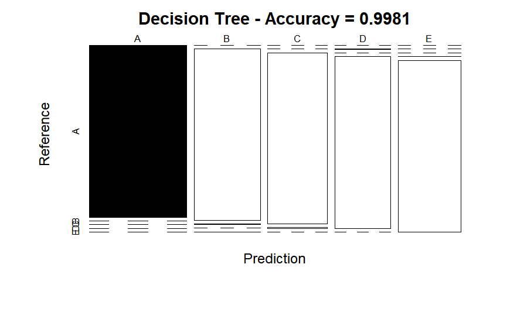

```r
plot(cm_rf$table,
     col = cm_rf$byClass,
     main = paste("Decision Tree - Accuracy =",
                  round(cm_rf$overall['Accuracy'],
                        4)))
```

## 4. Prediction / Application

Since the random forest model shows the highest accuracy, we use it for our prediction task. The 20 test cases are predicted to be:

```r
predict_task <- predict(fit_rf, task_final)
predict_task
```

```
 [1] B A B A A E D B A A B C B A E E A B B B
Levels: A B C D E
```

by Boris Blazej, 08.03.2022